# Instabilidade institucional e a rotatividade dos comissionados

2024-07-21

## Introdução

## Mudanças na “Caixa de Ferramentas”

O presidencialismo de coalizão e suas ferramentas não são elementos estáticos – uma lei que se aplica independentemente do contexto. Mudanças estruturais podem levar a alterações também no equilíbrio das forças do presidencialismo de coalizão. Ferramentas ganham e perdem força, a governabilidade pode se tornar mais fácil ou mais difícil de se conseguir.

*“Choques externos (crises econômicas, desemprego, inflação etc.) e internos (reformas ministeriais, eleições de meio de mandato para prefeitos, escândalos de corrupção etc.) também podem impactar decisivamente o equilíbrio e utilidades que o presidente e seus parceiros derivam do jogo da coalizão”*(BERTHOLINI; PEREIRA, 2017, p. 535)

## Hipótese

A hipótese a ser testada nesse trabalho é de que o processo de impeachment de Dilma Rousseff (PT) afetou um dos principais itens da “caixa de ferramentas” (RAILE, PEREIRA e POWER, 2011) que o presidente da República, como chefe do Poder Executivo, dispõe para formação de uma coalizão majoritária no Parlamento: os cargos de comissão.

Em resumo: o impeachment de Dilma deve ter resultado em um maior custo de coalizão e, portanto, uma maior rotatividade dos servidores comissionados.

## Comissionados?

O trabalho considera os **cargos de livre provimento**, sobre os quais o chefe do Executivo pode dispor livremente, contratando ou demitindo seus ocupantes no momento que desejar. São cargos que dependem de confiança, normalmente de direção, chefia ou assessoramento.

## Os dados

## Origem

- Base de dados de elaboração própria, com base nos dados do Portal da Transparência. Os dados disponíveis vão de janeiro de 2013 aos dias atuais.
- Os dados precisaram ser unificados, tratados e analisados com ajuda do software computacional R.

## O que será considerado rotatividade?

*“A rotatividade deve ser definida em função de todas as alterações de cargos ocorridas no ano [ou no período a ser estudado], ou seja, deve-se subtrair de 100% apenas o percentual de funcionários que não sofreram qualquer alteração em seus contratos”*

A Rotatividade percentual no órgão “i” e no período “t” ( \(Rotatividade\_{it}\) ) é igual à diferença entre “os trabalhadores inalterados” ( \(Inalterados_{it}\) ) em determinado período e o total de servidores computados no mês anterior ( \(Total_{it-1}\) ) (que resulta nos que sofreram algum tipo de alteração, como entrada, saída ou realocação), dividido pelo total de servidores computados no mês anterior ( \(Total_{it-1}\) ).

\[ Rotatividade_{it} = \frac{Total_{it-1} - Inalterados_{it}}{Total_{it-1}} \]

## Base de dados final

Rotatividade mensal dos servidores comissionados Executivo Federal (parcial)

[output not shown]

## Análise

## Evolução

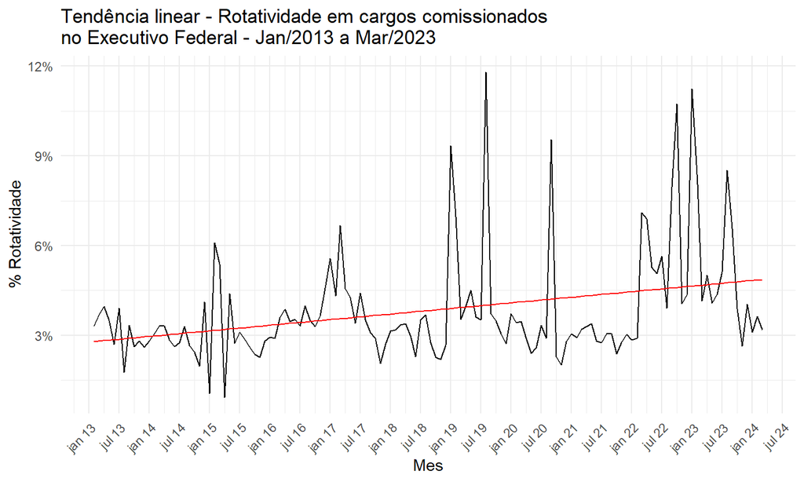

## Achados

- Tendência crescente na rotatividade dos cargos comissionados;

## Efeito das eleições

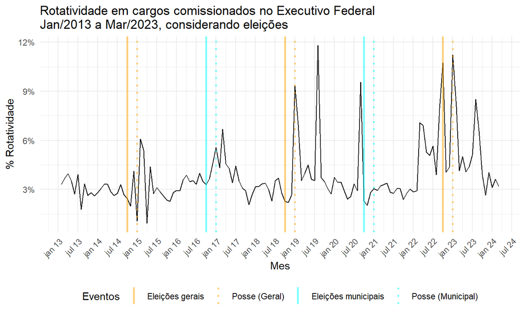

## Achados

- Eleições geram efeitos na rotatividade de pessoal, havendo picos muito claros em janeiro de 2019 (posse de Jair Bolsonaro) e janeiro de 2023 (posse de Lula, em seu terceiro mandato).
- A intensidade da rotatividade próximas às eleições, o que parece ser natural, aumentou com o tempo e que outros períodos de maior rotatividade se tornaram mais frequentes fora do período eleitoral.

## Antes e depois do Impeachment

## Impeachment afetou a rotatividade?

Para verificar se o impeachment teve efeito na rotatividade, separamos os dados mensais anteriores e posteriores ao impeachment.

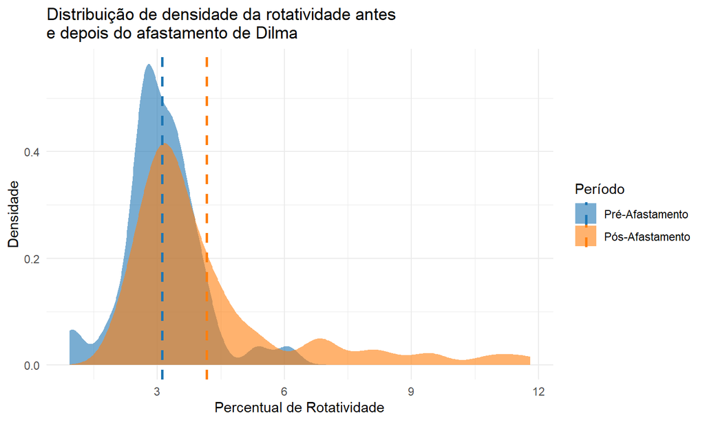

## Achados

No gráfico, é possível ver que antes do impeachment, a rotatividade se concentra antes de 7%, tendo um pico inferior a 3%. No período pós-impeachment, há o registro de meses de rotatividades mais altas, beirando os 12%.

## Testando a correlação

Resultados do Teste t de Student

Comparação das médias de percent_rotat por pos_imp

| estimate | estimate1 | estimate2 | statistic | p.value | parameter | conf.low | conf.high | method | alternative |
| --- | --- | --- | --- | --- | --- | --- | --- | --- | --- |
| -1.055805 | 3.117286 | 4.17309 | -4.102183 | 7.106448e-05 | 132.4184 | -1.564906 | -0.5467039 | Welch Two Sample t-test | two.sided |

## Traduzindo os resultados:

- A média de rotatividade no período pré-impeachment é de aproximadamente 3,12%. A média pós-impeachment é de aproximadamente 4,17%.
- A **média mensal de rotatividade dos servidores comissionados é menor antes do afastamento de Dilma** **e maior após o afastamento**.
- A **diferença entre os dois momentos observados é estatisticamente significativa.**

## Referências

ABRANCHES, Sérgio. **Presidencialismo de coalizão: o dilema institucional brasileiro**. Dados – Revista de Ciências Sociais, Rio de Janeiro, v. 31, n. 1, p. 5-38, 1988.

RAILE, Eric; PEREIRA, Carlos; POWER, Timothy. The executive toolbox: building legislative support in a multiparty presidential regime. Political Research Quarterly, Salt Lake City, v. 64, n. 2, p. 323-334, 2011. Disponível em: https://www.jstor.org/stable/23056394. Acesso em: 20 jul. 2023.

LOPEZ, Felix; BUGARIN, Maurício; BUGARIN, Karina. Mudanças Político-Partidárias e Rotatividade dos Cargos de Confiança (1999-2013). In: LOPEZ, Felix Garcia. C**argos de confiança no presidencialismo de coalizão brasileiro**. Brasília: Instituto de Pesquisa Econômica Aplicada (IPEA), 2015. cap. 1, p. 33-70.

BERTHOLINI, Frederico; PEREIRA, Carlos. Pagando o preço de governar: custos de gerência de coalizão no presidencialismo brasileiro. Revista de Administração Pública, Rio de Janeiro, v. 51, n. 4, p. 528-551, jul./ago. 2017. Disponível em: https://www.scielo.br/j/rap/a/9przPh6zP4sTwMds84qcj3B/?lang=pt. Acesso em: 21 jul. 2024.